# Can government public communications elicit undue trust? Exploring the interaction between symbols and substantive information in communications

Saar Alon-Barkat**, PhD candidate; the Hebrew University of Jerusalem; saar.barkat@mail.huji.ac.il

Last edited at 2019-03-15.[^1]

# Abstract

*Effective public communications have been proposed as a remedy for citizens’ distrust in government. Those studies that have explored the effectiveness of government communications have focused mainly on the extent to which they provide substantive information about bureaucracies’ performance and policies. Recently, a few studies pointed to the effect of symbolic elements, entangled in these communications (e.g. logos, images and celebrities). Still we lack theoretical understanding of the mechanisms underlying citizens’ responses to symbolic elements, and the interaction between symbols and substantive information. Building on the social psychology Elaboration Likelihood Model I hypothesize that symbols increase citizens’ trust in two ways: First, directly, by evoking positive feelings that are transferred to the organizations and policies presented in the communication. Second, indirectly, by conducing citizens to pay less attention to the substantive information in the communication. As a result, citizens disregard logically unpersuasive information that could decrease their trust. I examine these expectations via a survey experiment, focusing on the Israeli Environment Protection Ministry. The results support the hypotheses and suggest that the effect of symbolic elements is stronger when communications include logically unpersuasive information. I discuss the implications of these findings for democratic responsiveness and accountability.*

# Introduction

Scholars of Political-Science and Public-Administration are long concerned about citizens’ low trust in government, and their underestimation of public-service performance (Alford, 2001; Levi & Stoker, 2000; Nye, Zelikow, & King, 1997; Van de Walle & Van Roosbroek, 2008; Van Ryzin, 2011; Vigoda-Gadot, 2006). Distrust in public organizations may hamper citizens’ collaboration with organizations’ policies, and in turn, affect their successful implementation. It may also encourage citizens’ tax evasion and selection of private over public service providers, and it could make it more difficult for public sector organizations to attract and keep high-quality employees (Hvidman, 2018).

One of the main remedies proposed for this is greater investment in direct government communications to citizens. Congruently, over the past generation, economically-developed democratic countries have witnessed an increase in government public communications, specifically through advertising, social media, and e-government platforms (M. J. Canel & Sanders, 2013; Eshuis & Klijn, 2012; Marland, Lewis, & Flanagan, 2017; Mergel & Bretschneider, 2013; Mickoleit, 2014). In the US, for example, federal government agencies spend approximately 1.5 Billion dollars annually on contracts related to public relations and advertising activities in traditional and digital media (United States Government Accountability Office, 2017).

Extant research on the effect of government public communications on citizens trust has mostly focused on the *informative* aspects of these communications, whereby government organizations provide citizens with evidence about their performance and details and explanations about their policies and actions (Grimmelikhuijsen & Meijer, 2015; Ho & Cho, 2017; T. Im, Cho, Porumbescu, & Park, 2014; e.g. Marvel, 2015a; Porumbescu, 2016; Porumbescu, Lindeman, Ceka, & Cucciniello, 2017; Porumbescu, Neshkova, & Huntoon, 2018). This focus on information and transparency is in line with the positive normative view of government public communication and public relations, as articulated by the public administration literature on this topic, led by the works of Merdechai Lee. Communications with citizens are perceived as a means for accomplishing democratic accountability, facilitating the effective implementation of their missions, and aligning citizens’ perceptions of public organizations with their actual performance (M. J. Canel & Sanders, 2013; Lee, 2000, 2001, 2008, 2011; Lee, Neeley, & Stewart, 2012). Importantly, according to this view, public communications are expected to increase citizens’ trust in bureaucracies mainly insofar as these communications provide citizens with favorable information on the performance of organizations and logically persuasive explanations for their policies.

Recently, however, a few studies pointed to the additional effect of *symbolic* elements that are entangled in government communications, such as agencies’ names and brand logos, figures, images and celebrity endorsements (Alon-Barkat & Gilad, 2017; Karens, Eshuis, Klijn, & Voets, 2016; Teodoro & An, 2018). These studies experimentally demonstrated that government organizations may cause citizens to view them more favorably and trust them through familiar and well-designed symbolic elements that evoke positive associations and emotions. Still, we lack a theory and robust empirical evidence of the exact mechanisms through which these symbols increase citizens’ trust. These studies also did not examine the interaction between the symbolic elements and the substantive content of information in public communications.

This research gap has normative significance. Whereas the responsiveness of citizens to substantive information is perceived favorably from a democratic standpoint (assuming that it is accurate), establishing trust through symbolic elements can be highly problematic. Shaping citizens’ perceptions of governments by evoking associations and emotions stands against the normative expectation that citizens’ judgments should be based on their critical thinking. Furthermore, we need to be aware that symbolic communication may elicit undue trust in poorly performing organizations and in ill-conceived policies, and enable public organizations to escape justified public criticism (Alon-Barkat & Gilad, 2017). Therefore, this study focuses on the following questions: *What are the psychological mechanisms by which symbolic elements in government communications affect citizens’ trust in government organizations and their policies? Does the effect of symbolic elements on trust depend on the substantive content of communications?* *Do symbols offset the rational, negative effect of unfavorable or logically unpersuasive information?*

To address these research questions, I draw upon the social psychology Elaboration Likelihood Model (ELM). ELM provides a comprehensive theoretical framework for various psychological processes underlying individuals’ responses to persuasive communication, and their consequences for attitude change (R. E. Petty & Briñol, 2011; R. E. Petty & Cacioppo, 1986). Based on ELM, I suggest that symbolic elements in public communications can affect citizens’ trust in two ways: *First*, they may evoke positive feelings and associations that are transferred from the symbols to the relevant government entities and policies, and thereby increase citizens’ trust in them. *Second*, symbolic elements may increase citizens’ trust in government entities and policies by causing them to disregard the content of logically unpersuasive information that could otherwise decreased their trust.

To empirically test these theoretical expectations, I conducted a large randomized survey experiment among circa 860 Israeli citizens. The experiment focuses on the empirical case of the Israeli Environment Protection Ministry. I explore citizens’ responses to public communications about two policy plans of the Ministry. Specifically, I examine how their trust in these public policies is affected by the symbolic elements in the communications (real symbols vs. fake symbols and no symbols conditions) as well as by the substantive information in them (logically persuasive vs. unpersuasive policy plans).

I found that the symbolic elements increased citizens’ trust in these policies. In line with my theoretical expectations, the effect was greater among those who saw the logically unpersuasive policy plans. The latter were less inclined to think about the weak, unpersuasive content, because they were distracted by the symbols. I discuss the theoretical and normative implications of these findings.

# Symbolic elements in government communications and their shaping of citizens’ attitudes: what do we know?

A symbol can be broadly defined as *“any object used by human beings to index meanings that are not inherent in, nor discernible from, the object itself”* (Elder & Cobb, 1983, pp. 28–29). Symbols are fundamental for almost any form of human interaction, and specifically in the context of politics and public affairs (M. Edelman, 1964; M. J. (. J. Edelman, 1988; Elder & Cobb, 1983). Conselletions of symbols in discourse form consolidated narratives, which play an key role in shaping people’s perceptions of policy problems and solutions (H. Miller, 2012; H. T. Miller, 2015).

My focus in this study is on those symbols that are strategically used by government organizations in their public communications, are designed to distinguish them and to evoke associations and emotions that stimulate audiences’ positive affect towards organizations and their operations. Prominent examples are unique logos, colors associated with specific meanings, icons, images, and the use of celebrities as endorsers. These elements are widely used by businesses and political candidates to attract targeted consumers and voters. Yet, they can also be found in the communications of government bureaucracies with citizens, including their mass-media advertising campaigns, social media accounts, internet pages, official publications, signboards in public places and personal mail notifications to citizens.

In comparison with the abundant research on the effect of informative elements in public communications on public trust (for reviews see: Cucciniello, Porumbescu, & Grimmelikhuijsen, 2016; Grimmelikhuijsen & Knies, 2017; James & Van Ryzin, 2017b), public administration literature has devoted relatively little attention to the effect of symbolic elements. Recently, however, a few experimental studies tackled the issue. Marvel (2015b) analyzed US citizens’ responses to a television advertisement of the public US Postal Service, which involved various symbolic elements, including the organization’s logo, workers’ images and background music. His study shows that participants who watched the advertisement evaluated the organization’s performance more positively. Teodoro & An (2018) suggested that the names of US federal agencies not only represent information about their activities, but may also carry specific symbolic meaning and positive/negative “affect” that can shape citizens’ support for government policies (depending on citizens’ political party identification). While these two studies provide examples for the role of symbols in shaping citizens’ trust and performance evaluation, they did not effectively disentangle the effects of the symbolic and informational aspects of the public communications studied.

A study by Karens et al. (2016) did examine the distinct effect of symbols in communications on citizens’ trust in bureaucracies. The scholars surveyed university students from three European countries and examined their trust in two policy plans of the European Commission, and it’s shaping by the appearance of its logo in the communication. They found that including the Commission’s logo significantly increased citizens’ trust in these policies. Their results show an impressive effect size equivalent to 0.7 standard deviations, on average.

Alon-Barkat & Gilad (2017) examined Israeli citizens’ trust in the Israel Electricity Corporation, a state owned company, and it’s shaping by their exposure to comic cartoon figures that were routinely presented in the organization’s public campaigns. They compared citizens who were personally exposed to prolonged power outages and others who were not. They found that the symbolic element had a positive effect on citizens’ trust in the organization, including among those who personally experienced poor performance (a modest effect size equivalent to 0.25 standard deviations). Building on social psychology theory and marketing research, they suggested that the symbols enhance trust by inducing an unconscious transfer of affect from the symbols to the organizations and policies associated with them (“evaluative conditioning”). They proposed that the effectiveness of government symbolic elements depends on their familiarity, and aesthetic design, as well as on the ambiguity of the government quality assessed.

The aforementioned studies tend to suggest that public communications increase citizens’ trust in government organizations and their policies, not only by conveying valuable substantive information, but also by incorporating symbolic elements that evoke positive associations and emotions. Moreover, the findings of Alon-Barkat & Gilad (2017) suggest that incorporating symbolic elements in public communications can unduly compensate for poor government performance, thus pointing to their potential detrimental implications.

Even though these studies substantiate a link between the appearance of symbolic elements in communications and citizens’ greater trust in public organizations and policies, they did not directly investigate the causal mechanisms that underlie this effect. Therefore, we still lack understanding of the circumstances under which symbols are likely to be more/less effective in shaping citizens’ trust. Specifically, these studies neither theorized nor empirically tested the interaction between symbolic elements and citizens’ processing of substantive information in communications. We do not know whether well-designed symbols reinforce, or offset, citizens’ rational responses to information. Specifically, as explained above, it is essential to assess the possibility that symbols can unduly compensate for unfavorable or logically unpersuasive information that should yield negative responses.

To address this theoretical gap in public administration research, I propose a nuanced theoretical framework for the effects of symbols in communications and their interaction with information, building on social psychology theory on persuasive communication.

# The Elaboration Likelihood Model and the various mechanisms of persuasion by elements in communications

The social psychology Elaboration Likelihood Model (ELM) provides a comprehensive theoretical framework for investigating peoples’ varying responses to “persuasive” communications (R. E. Petty & Briñol, 2011; R. E. Petty & Cacioppo, 1986). It theorizes when and how individuals are more/less likely to change their attitudes following a communication or a message. Accordingly, ELM can be applied to various settings, types of attitudes and forms of communications. It has been specifically applied to studies on persuasion or attitudinal change in various areas, including commercial advertising (Dotson & Hyatt, 2000; Moore & Reardon, 1987; e.g. R. E. Petty, Cacioppo, & Schumann, 1983; Wheeler, Petty, & Bizer, 2005), public health campaigns (Angst & Agarwal, 2009; Briñol & Petty, 2006; Ruiter, Kok, Verplanken, & Brug, 2001; Wilson, 2007), media coverage (R. E. Petty, Priester, & Brinol, 2002; Wurff, De Swert, & Lecheler, 2016) and media entertainment (Slater & Rouner, 2002; D. G. Young, 2008). So far however the relevance of ELM has not been directly examined in relation to changes in citizens’ trust in public organizations in response to their public communications.

According to ELM, the responses of individuals to persuasive communications depends on how much effort they devote to thinking about the content of the message (or “the amount of thinking” according to ELM terminology). Persuasion, or attitudinal change, can occur when thinking is “high” or “low”, but the processes and consequences are likely to differ in each situation. This range between high and low degrees of thought is referred to as the “elaboration continuum”. People’s location along this continuum is associated with different psychological processes of persuasion. At the high end of the elaboration continuum, also called the “central route”, people are likely to respond by cognitively scrutinizing the arguments central to the merits of the issue. At the low end, also called “the peripheral route” people respond to simple cues automatically and unconsciously through primitive psychological processes that require very little cognitive effort, such as an unconscious transfer of affect[^2]. In turn, these two mechanisms are likely to cause divergent types of persuasion. Persuasion via the central route is expected to be more enduring, resistant and predictive of behavior, compared with the peripheral route. Of course, often people are located in between the two ends of the continuum, and thus persuasion is determined by a combination of these processes.

ELM enables us to disentangle the distinct effects of different elements in communications. Some elements are processed differently by people at different locations along the elaboration continuum. Consider for instance a text that contains a series of logical arguments supporting a certain position. Those at the high end of the continuum would regard this element as argumentation. They would systematically scrutinize it and form their attitudes about the position based on its logical persuasive quality (central route processing). Stronger arguments would increase their inclination to support the position (i.e. to form positive attitudes about it). Conversely, those at the low end of the continuum are more likely to disregard the content of the text, and instead, rely on the number of lines in it, for example, as a cue for its strength (peripheral route processing). Some elements provide potential cues that lack any logical quality at all. For example, the physical attractiveness of the source normally does not represent any substantive argument, yet it can serve as a simple cue. Accordingly, they may affect the attitudes of those at the low end, but are less likely to persuade those at the high end (R. E. Petty & Cacioppo, 1986).

ELM further postulates that the placement of people along the elaboration continuum in any given situation is determined by their *motivation* and *ability* to think about the message. Accordingly, the literature proposes a variety of such motivational and ability factors. Among others, studies have demonstrated that the more people are distracted, the more difficult it is for them to scrutinize the message arguments, a mechanism that has been referred to as “elaboration disruption” (R. E. Petty & Cacioppo, 1986; R. E. Petty, Wells, & Brock, 1976). Another prominent factor that influences people’s inclination to elaborate on the message is their affective state, or mood. Positive mood (compared with neutral or negative moods) reduces people’s cognitive ability and attenuates their motivation to think, due to their desire to maintain their positive mood and avoid message processing that would depress it (Bless, Bohner, & Schwarz, 1990; Mackie & Worth, 1989; R. Petty, Cacioppo, & Kasmer, 2015; Schwarz, Bless, & Bohner, 1991; but see: D. Wegener, Petty, & Smith, 1995; Worth & Mackie, 1987).[^3] Affecting the amount of thinking can cause attitude change in interaction with elements in the communication that can function as arguments or peripheral cues. Decreasing the amount of thinking weakens the effect of substantive arguments and enhances the effect of peripheral cues (and vice versa).

Elements in communications can also function as factors that affect people’s motivation and/or ability to think. For example, Background music in commercials can distract people and prevent them from scrutinizing their content (C. W. Park & Young, 1986). The use of humor in television shows stimulates positive mood and reduces people’s ability and motivation to scrutinize their substantive arguments (Nabi, Moyer-Gusé, & Byrne, 2007; D. G. Young, 2008). Hence, elements can have more than one function, and can shape attitudes through several mechanisms. They can serve both as variables that affect the amount of thinking and as potential peripheral cues or arguments. Continuing with the above-mentioned examples, background music and humor can serve as simple cues that persuade people directly through the peripheral route, yet at the same time they can also act as factors that reduce elaboration. Accordingly, they can affect people both directly (as peripheral cues) and indirectly (by decreasing elaboration and thus attenuating the effect of arguments and enhancing the effect of peripheral cues).

# ELM and the roles of symbolic elements and information in government public communications

How may we apply the theoretical framework of ELM to the study of the effects of symbolic elements in government communications on citizens’ trust and their interaction with substantive information?

In light of the conceptualization of ELM, substantive information elements in government public communications represent issue-related arguments, which can be scrutinized or processed systematically based on their logical quality (via the central route), at least by those who are sufficiently motivated and able to do so. More positive information about organizations’ performance and more logically persuasive arguments supporting their actions would increase citizens’ trust in these organizations and their actions and vice versa. Conversely, symbolic elements are potential peripheral cues. they can increase citizens’ trust via the peripheral route, by evoking positive emotions and associations that are attributed to government organizations and their policies (Alon-Barkat & Gilad, 2017). However, in addition to their direct effect as peripheral cues, symbolic elements may also increase citizens’ trust indirectly. They can decrease the amount of thought citizens dedicate to the communication, and thus prevent them from scrutinizing substantive information that would otherwise decrease their trust, namely negative information (e.g. information on poor performance) and weak arguments (e.g. logically unpersuasive arguments supporting their actions and policies). The latter assertion entails an interaction between symbols and the substantive information in communications: symbolic elements in public communications are more likely to affect citizens’ trust when communications include negative information or weak logical arguments.[^4]

How can symbolic elements decrease citizens’ ability and motivation to think about the message? According to social psychology theory, they can do so in two main ways. First, they can cause elaboration disruption, by distracting citizens and capturing their attention and cognitive efforts (R. E. Petty & Cacioppo, 1986; R. E. Petty et al., 1976). Second, they can decrease citizens’ motivation and ability to think about the message content by creating a positive affect and placing citizens in a positive mood. As explained above, the postulation that positive mood decreases elaboration has been explained, in part, by a mood maintenance mechanism (Bless et al., 1990; Mackie & Worth, 1989; Schwarz et al., 1991). This mechanism is particularly relevant to the context of government communications, in which thinking about the content of the message – government organizations and policies – is likely to yield a negative mood among most people (Hvidman & Andersen, 2016; Marvel, 2015a, 2015b). Therefore, when citizens are exposed to symbolic elements that evoke positive feelings, they may seek to avoid thinking about tedious bureaucratic affairs, which would depress their positive mood.

In summary, I expect that:

*H<sub>1</sub> - Symbolic elements in public organizations’ communications are likely to increase citizens’ trust in those organizations and in the policies presented in their communications.*

*H<sub>2</sub> - The positive effect of symbolic elements on citizens’ trust is likely to be enhanced when the communication includes negative or logically unpersuasive information that could otherwise have decreased citizens’ trust.*

*H<sub>3</sub> - Symbolic elements are likely to decrease the amount of thinking about the content of the communication.*

*H<sub>4</sub> - The abovementioned moderated effect of symbolic elements on citizens’ trust (H<sub>2</sub>) is likely to be mediated by their negative effect on citizens’ amount of thinking (H<sub>3</sub>) - a moderated mediation hypothesis.*

# Methodology

To empirically test the above mentioned hypotheses, I designed a randomized survey experiment, which simulates citizens’ responses to government organizations’ communications about their policy plans. Such communications can be found in publicized reports, pamphlets, websites, new media pages and ads. I focus on communication of future policy plans, as opposed to communications on performance of existing policies. This allows me to utilize a real-world empirical case, yet still to manipulate the content of the communication in a reliable manner. Most citizens do not have prior knowledge of organizations’ future policy plans, and will therefore be more willing to trust a fictional communication of an organization with regard to its future policy.

In addition to the above-mentioned hypotheses, the experiment was also designed to test a different set of hypotheses regarding the interaction between symbols and the perceived personal relevance of communications. The selection of policy plans and the construction of the population sample were designed to account for variation in that variable. In this paper, however, I focus on those methodological and empirical parts of the study that are consequential for the examination of the interaction between symbols and information.[^5]

## *The empirical case*

The empirical setting of this experiment relates to the Israeli Environment Protection Ministry (hereafter: EPM) that is responsible for the formulation, co-ordination and execution of environmental policy in Israel, at the national and local levels. I analyzed the effects of informative and symbolic elements in the EPM’s communications of two policy plans on citizens’ trust in these policies, and the extent to which they elaborated on them. In the survey, the communications about the two policy plans, in which I manipulated the informative and symbolic elements, are presented to the participants as sections from the EPM’s official publication of its annual work plan.

Methodologically, the EPM is a good candidate for this study due to its significant investment, over the past years, in public communications. In these communications, the EPM used an array of symbolic elements, which became widely recognized by the public. Here, I focused on three prominent symbolic elements used in the EPM’s public communications, and displayed below in **Figure 1**. The first symbolic element is the unique brand logo of the EPM (Figure 1a). This logo consists of a pair of green and orange leaves that resemble two hands, designed to symbolize peace and harmony with the environment. The second symbolic element which I focused on, is the color green, which is strongly associated with environmental protection. The EPM logo and the green color are used in almost all of EPM’s visual communications, and they represent key elements of its unique “visual identity” (Van den Bosch, De Jong, & Elving, 2005). The third element is celebrity endorsements. Specifically, I selected two high-profile celebrity comedians, *Tal Friedman* and *Ido Rosenblum*, who previously endorsed two salient advertising campaigns of the EPM. The campaign starring the comedian Tal Friedman (Figure 1b) was launched in 2010, and included a series of advertisements in which Friedman was presented with a head covered in green grass, and accordingly the campaign’s slogan was: “starting to think green”. The campaign starring the comedian Ido Rosenblum (Figure 1c) was launched in 2017, and focused on reducing the use of disposable bags.[^6] The two campaigns were highly successful in terms of their recognizability and likability, as suggested by their evaluation reports by the Government advertising agency.

In the course of the survey experiment, I was able to confirm that the EPA logo and the images of the celebrities from the campaigns were familiar to the participants. A total of 67% of the participants reported that they recognize the EPA logo to some extent, and a vast majority of them reported that they recognize the campaign images of Friedman and Rosenblum (83% and 71%, respectively). In robust analyses I further exclude those who do not recognize these symbols.[^7]

**Figure 1: Symbolic elements of EPM**

[figure not shown]

*Notes:*

1. EPM logo.
2. Tal Friedman, comedian, EPM campaign “starting to think green” (2010): “Isn’t money growing on trees? Moving to environmental consumption and saving at least 6,000 NIS per year!”, “starting to think green”, “The Environmental Protection Ministry”.
3. Ido Rosenblum, comedian, EPM campaign “taking every bag seriously” (2017): “Did you forget your reusable carrier bag at home again? A tip from Ido: Hang it on the door handle and you will not leave without it”, “Taking every bag seriously”, “The Environmental Protection Ministry”.

## *Procedure and sample population*

The survey was presented to the participants as a study about citizens’ attitudes regarding environmental policy issues. The participants were first asked to respond to pre-manipulation questions about their political ideology and their perceptions of the public sector.[^8] Thereafter, they were told that they would be presented with two government policy plans regarding specific environmental issues, extracted from EPM’s official 2018 annual work plan. The policy plans included reducing air-pollution in Haifa bay area in the north of Israel, reducing domestic waste and increasing recycling. The two policy plans were presented to each subject in a random order. Each policy plan included the title of the policy goal (e.g. “reducing the levels of air pollution in the Haifa bay”), followed by short descriptions of two actions to be taken by EPM in order to fulfill this goal (30-50 words each).

Per each policy, subjects were randomly allocated to one of two conditions of substantive information (hereafter: information): strong policy (i.e. logically persuasive policy plan) or weak policy (i.e. logically unpersuasive). Each subject, moreover, was exposed to one strong and one weak policy communication. So for example a subject who first received a strong air-pollution policy plan, later received the weak recycling policy plan, and vice versa. The actions which were mentioned in the condition of the strong policy plans were taken from the real EPM work plan and from other reports and official EPM sources. The activities that were included in the weak policy plans condition were fictional, and were designed to represent measures that are likely to be perceived by subjects as extremely incompatible with achieving the policy goals, yet still sufficiently reliable. For instance, the proposed actions for the strong air-pollution policy involved increasing the supervision of polluting factories, and reducing diesel smoke emissions by vehicles, whereas the actions for the weak policy were to decrease the supervision of polluting factories, and raise citizens’ awareness of the Ministry’s efforts to improve air quality. The full texts of the weak and strong conditions for the two policy plans is included in **Appendix A**.

In addition to information manipulation, the participants were randomly assigned to one of three conditions of symbolic elements in the communication (hereafter: symbols): treatment (“real symbols”), control-“no symbols” and control-“fake symbols”. In the symbol treatment condition, the two policies (again, one weak and one strong) were displayed with the above-mentioned three symbolic elements: the titles and the footer were colored green, the EPM logo was displayed at the top of the page, and the celebrities’ images from the campaigns were attached and labeled “EPM advertisement”. Each communication included the image of one celebrity: Rosenblum’s image from the campaign for reducing the use of disposable bags was attached to the recycling policy; Friedman’s image from the “starting to think green” campaign was attached to the air-pollution policy.

In the control no-symbols condition, the two policies were displayed in a minimal black and white design, and without the logo and the celebrities’ images. In the control fake-symbols condition, the green color was replaced with blue, the EPM logo was replaced by a fake logo and the images of celebrities from the campaigns were replaced with two edited images of unfamiliar people. The purpose of the fake-logo condition was to isolate the symbolic meaning of the EPM’s graphic identifiers and distinguish it from the possible effect of their aesthetic design. Accordingly, I specifically designed the “fake” symbols so that they would resemble the real symbols and have equivalent aesthetic qualities, without activating emotions and associations which could be attached to the government ministry and environmental issues. In that sense, the “fake” symbols could be regarded as a placebo.

The symbols conditions are displayed in **Appendix B**. Further details about the images in the real and fake symbols conditions are found in the supplementary appendix. Each subject received two policies which were presented under the same symbol condition, but under different information conditions (i.e. one strong and one weak). This allowed me later to analyze the interaction between these two manipulations both between and within-subjects.

Each policy plan was followed by six questions about respondents’ trust in the policy. Next, the subjects underwent a memory test on the last policy that was presented to them, and they were asked about the extent to which they elaborated on it and about the personal relevance of the policy plans. The following step included an Instructional Manipulation Check (IMC) item, intended to assess participants’ diligence. After a set of demographic questions, I conducted a manipulation check, in which I asked the participants whether they recognize the Ministry’s logo, and the two celebrities’ images. Finally, the participants were debriefed about the manipulations, and the possible deception. An English translation of the full survey is available in the supplementary Appendix.

Altogether, for each policy plan, the survey experiment has a factorial design of 3 (symbols: real symbols, fake-symbols, no-symbols) x 2 (information: strong vs. weak policy). The assignment to the different experimental groups is graphically presented in **Figure 2**. The experimental groups are balanced with respect to demographics, and pre-manipulation variables. Throughout the rest of the paper, I will analyze the results at the policy level, in order to simplify the analyses. Accordingly, I transformed the dataset into a multilevel structure of policies nested within subjects.[^9]

**Figure 2: Experimental design for policy plan communications**

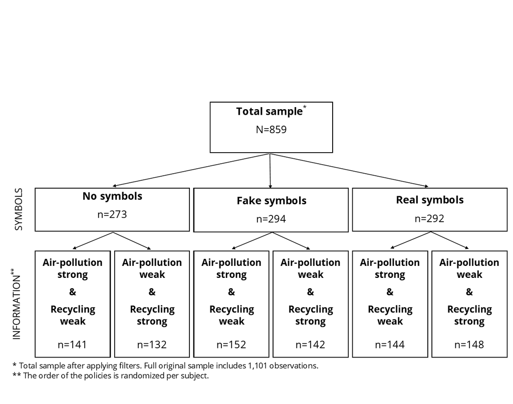

The survey experiment was conducted online using Qualtrics Survey Software. The subjects, adult Israeli citizens, were recruited via an Israeli internet research panel company called *iPanel.* The online survey link was sent by iPanel, between the dates 28.1-1.2.2018 to 5,077 people. A total of 1101 respondents completed the survey (a response rate of 21.7%). Of these, I later filtered out 242 observations (22%) due to multiple entries from the same IP address (n=32); failure at the instructional manipulation test (n=125); surveys that were submitted in less than 3 or more than 30 minutes (n=37); and respondents under the age of 18 (n=48). These filters are not significantly associated with the experimental conditions. Ultimately, following this rigorous screening, I ended up with a sizable sample of 859 subjects (Mean age = 36.3, 49.8% women).[^10] Because each subject evaluated two different policy plans, my dataset has a multilevel structure of 1718 observations nested within these 859 subjects.

## *Operationalization of variables*

The main independent variables are the above mentioned manipulations for information and symbols, and the interaction between them. The outcome variable is citizens’ trust in policy (or the perceived trustworthiness of the policy). This variable is measured in the survey for each policy plan using a composite index of six likert scale items (Cronbach’s alpha = 0.93), which were adopted and slightly modified from validated trust scales used by previous public administration studies on trust in government (Grimmelikhuijsen & Knies, 2017; Grimmelikhuijsen & Meijer, 2014; Grimmelikhuijsen, Porumbescu, Hong, & Im, 2013; Karens et al., 2016; Porumbescu, 2016). Participants were asked to indicate their agreement with the following statements, between 1 (weakly agree) and 7(strongly agree): (1) I believe that the actions mentioned in the policy plan will assist in fulfilling the policy goal; (2) I believe that the actions mentioned in the policy plan were designed in a professional manner; (3) I believe that the policy plan is in the interest of citizens; (4) I believe that the policy plan reflects a genuine attempt to improve the well-being of citizens; (5) I believe that EPM made an honest attempt to design a good policy plan; (6) I believe that the Ministry of Environmental Protection aims to keep its commitments in that policy plan. The mean of this trust index is 4.23, the standard Deviations is 1.47 and the median is 4.5. Higher levels of trust are associated with higher trust in government, left-wing ideology and lower levels of education. In addition to measuring participants trust in each policy, I also calculated the delta of each subject’s trust in the strong and weak policy plans that were presented to them (*Mean* = 0.58, *SD* = 1.52, *Median* = 0.33). I use this Trust in policy delta to analyze the interaction between symbols and information within subjects.

To assess the levels of thinking or elaboration on the policy plans, I used two distinct measures: First, I counted the number of seconds participants spent on scanning each of the policy plans (hereafter – reaction time), log transformed to reduce skewness (*Mean* = 2.85, *SD* = 0.91). Second, I used a memory test, asking participants whether a list of four items were included in the policy plan, of which two were/were not included (participants could also select “I don’t know”). The memory score is calculated as the number of correct items selected by the participant minus the number of incorrect items, with a minimum score of zero. Accordingly, participants could receive the scores of 0 (433, 50.4%), 1 (228, 26.5%) or 2 (198, 23.1%).[^11] These two measures are correlated with each other (Spearman rho = 0.29), which substantiates their validity.

In addition to the independent variables above, the survey also included control items regarding respondents’ age, gender, education, income, home ownership, age of their children, political ideology, trust in government, interest in environmental issues and residence in the Haifa-bay area. Summary statistics and correlation matrix for all variables are available in the supplementary appendix.

# Results

I now turn to analyzing the experimental results. I begin by examining my first and second hypotheses, that regard the effect of symbols on trust and its interaction with information. Thereafter, I will examine hypotheses 3 and 4, that deal with the mediating role of elaboration. For each section, I conduct both *between-subjects* and *within-subjects* analyses.

## *The interaction between symbols and information*

According to the first hypothesis, I expect that the real symbols condition will have a positive main effect on subjects’ trust in the policy plans. According to my second hypothesis, I expect a positive interaction between the real symbols and weak policy plan. Namely, the effect of the real symbols is expected to be greater among those subjects who were assigned to the weak policy. In **Table 1**, I test these two hypotheses via regression analyses. To account for the multilevel structure of the data, I use GLS regressions with random intercept at the subject level via `lme4` R package (ICC1 = 0.39, ICC2 = 0.56). In Model 1 I regress trust in policy on the symbols manipulation. Thereafter, in Models 2 and 3, I add the information manipulation, and the interaction between them. The reference category for the symbols manipulation is the no-symbols condition.

**Table 1: Regression analyses – the effect of symbols on trust in policy**

|  | Trust in policy |  |  |
| --- | --- | --- | --- |
|  | (1) | (2) | (3) |
| Real symbols | .361*** | .361*** | .174 |
|  | (.102) | (.102) | (.121) |
| Fake symbols | .221** | .221** | .146 |
|  | (.102) | (.102) | (.120) |
| Weak policy (0=strong policy) |  | -.578*** | -.756*** |
|  |  | (.052) | (.092) |
| Weak policy x Real symbols |  |  | .374*** |
|  |  |  | (.127) |
| Weak policy x Fake symbols |  |  | .151 |
|  |  |  | (.127) |
| Constant | 4.030*** | 4.319*** | 4.408*** |
|  | (.074) | (.078) | (.087) |
| N | 1,718 | 1,718 | 1,718 |
| Log Likelihood | -3,026.463 | -2,970.514 | -2,968.587 |
| *Notes*: Table entries are non-standardized random-effect GLS regression coefficients, clustered at the subject level. Standard errors are in parentheses. The reference category for the symbols manipu… |  |  |  |

**p*<.1; ***p*<.05; ****p*<.01 (two-tailed).

**Figure 3: The effect of symbolic elements on trust under weak vs. strong information**

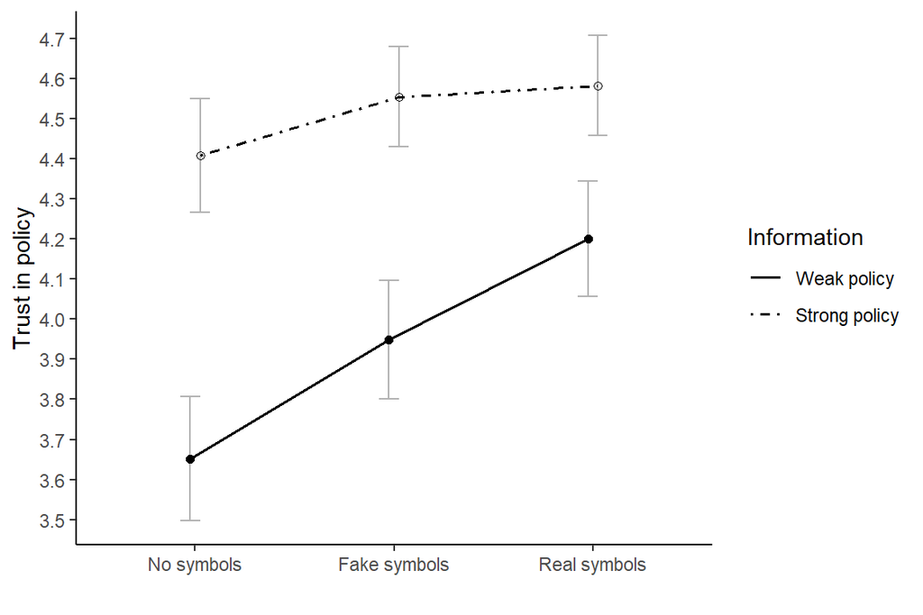

*Note*: Error bars represent 90% confidence intervals.

The interaction between symbols and information can also be tested *within-subjects*, by comparing the averaged delta across the different symbols conditions. Based on my second hypothesis, I expect that the averaged delta will be lower among subjects in the real symbols condition. This comparison is graphically displayed in **Figure 4**. The averaged delta in the real symbols is significantly lower than in the no symbols and fake symbols control groups (differences are 0.37 [0.13,0.62] and 0.22 [-0.01,0.46], *t*= 2.978 and 1.854, respectively). The differences between the two control groups are insignificant. These results further support my findings above that familiar symbols decrease subjects’ inclination to differentiate between the strong and weak policy plans.

**Figure 4: The effect of symbolic elements on within-subject delta between strong and weak policies**

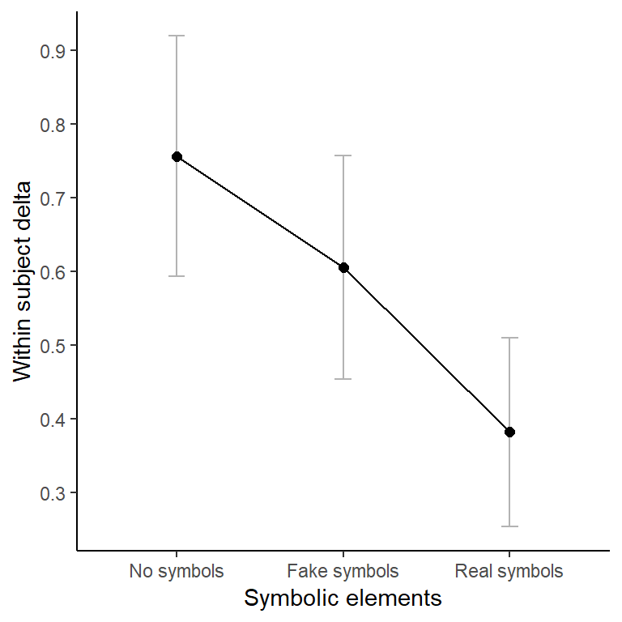

*Note*: Error bars represent 90% confidence intervals.

Altogether, the above between- and within-subject analyses largely support my first two hypotheses. They suggest that familiar, and to a lesser extent unfamiliar, symbolic elements in communications increase citizens’ trust in policies, and that the effect is greater for logically unpersuasive information. In other statistical models, shown in the supplementary appendix, I tested additional specifications, including analyzing the unfiltered sample, adding control variables, excluding subjects who did not recognize the real symbols and adding interactions with the policy plans. In all these robust analyses, the main effect of the real symbols remains positive and significant, and the interaction between the real symbols and the weak information remains positive and significant.

## *The mediating role of elaboration*

In the following section, I test the postulation that the interaction between symbols and information is explained or mediated by a decrease in elaboration. To reiterate, in the survey, I used reaction time (log) and memory score as measures for participants’ level of elaboration of the policy plans. Based on my third hypothesis, I expect to find a negative effect of the real symbols on these two measures. Thereafter, my fourth hypothesis entails moderated mediation relations: the decrease in elaboration mediates the effect of symbols on trust under the weak policy, but not under the strong policy.

In **Table 2**, I test the effects of the real symbols on the elaboration measures via regression analyses. I regressed each elaboration measure on the symbols manipulation (Models 2.1, 2.3), and then added the information manipulation (Models 2.2, 2.4). The first two models, which refer to reaction time, are random intercept models which are similar to the statistical models in **Table 1**. As for the memory score analyses, given that each subject was asked only about one policy (the second in order), I used an OLS regression.

**Table 2: Regression analyses – the effect of symbols on elaboration**

|  | Reaction time (log) |  | Memory score |  |
| --- | --- | --- | --- | --- |
|  | linear |  | OLS |  |
|  | mixed-effects |  |  |  |
|  | (1) | (2) | (3) | (4) |
| Real symbols | -.226*** | -.226*** | -.208*** | -.201*** |
|  | (.068) | (.068) | (.068) | (.067) |
| Fake symbols | -.083 | -.083 | -.079 | -.084 |
|  | (.068) | (.068) | (.068) | (.067) |
| Weak policy (0=strong policy) |  | .176*** |  | -.327*** |
|  |  | (.028) |  | (.054) |
| Constant | 2.959*** | 2.871*** | .824*** | .983*** |
|  | (.049) | (.051) | (.049) | (.055) |
| N | 1,718 | 1,718 | 859 | 859 |
| R<sup>2</sup> |  |  | .011 | .052 |
| Adjusted R<sup>2</sup> |  |  | .009 | .048 |
| Log Likelihood | -2,107.135 | -2,090.574 |  |  |
| *Notes*: Table entries are non-standardized regression coefficients. Standard errors are in parentheses. The reference category for the symbols manipulation conditions is the control no-symbols. |  |  |  |  |

**p*<.1; ***p*<.05; ****p*<.01 (two-tailed).

In all four models, the coefficients of the real symbols are negative and significant, and the coefficients of the fake symbols are insignificant. The real symbols decreased the number of second subjects spent on the pages of the policy plans in the online survey, compared with both control groups.[^12] The effect is significant at the 95% level compared with the no symbols condition (*Coef* = -0.23 [-0.36, -0.09]), yet it is not sufficiently significant compared with the fake symbols. The averaged memory score of subjects who saw the real symbols was significantly lower, compared with both the no logo and the fake logo groups (*Coef* = -0.21 [-0.34, -0.07], and -0.13 [-0.26, 0], respectively).[^13] There is no significant change to the results when adding the effects of the information manipulation (in Models 2.2, 2.4). The coefficients of the weak policy in these models suggest that those who saw the fictitious, weak policy plans, spent more time on their pages, yet were less likely to state items that were included in them. **Figure 5** displays the descriptive comparison of the elaboration measures across the symbols conditions. The left side shows its effect on reaction time (logged), and the right side shows its effect on the memory-test scores.

**Figure 5: The effect of symbolic elements on elaboration**

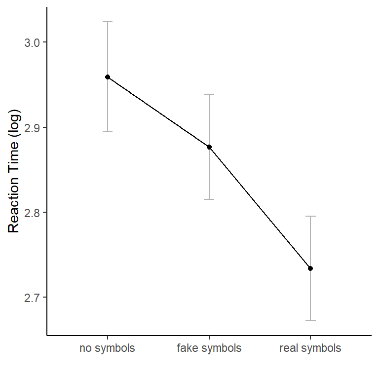

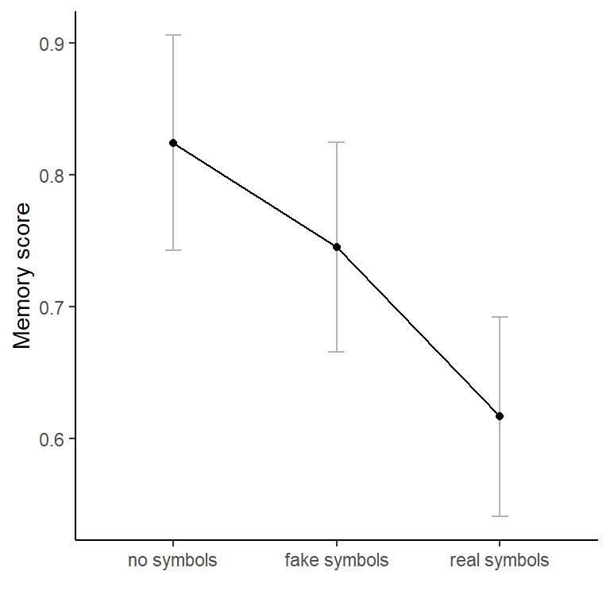

*Note*: Error bars represent 90% confidence intervals.

Next, I tested the hypothesis that the decrease in reaction time and memory score mediate the effect of the real symbols on trust in the weak policy plans. To do so, I used the causal mediation analysis method in the `mediate` R package, which was developed by Imai et al. (Kosuke Imai, Keele, & Tingley, 2010; KOSUKE Imai, Keele, Tingley, & Yamamoto, 2011), and was also recently implemented in Public Administration research (Porumbescu et al., 2018). This method predicts the change in the outcome variable (here: trust in policy) given the causal change in the mediator that would be induced by the treatment (here: decreased elaboration inducted by the real symbols). Accordingly, it allows me to decipher the proportion of the causal mediation effect from the total effect. Causal mediation analysis is based on counter-factual comparisons, as opposed to the traditional method of Baron & Kenny (1986), which is based on linear structural equation modeling. It has an advantage due to its accuracy as well as its ability to identify causality. **Table 3** displays the results of the causal mediation of reaction time (log) and memory test, under the weak policy plans. The analyses of reaction time includes those observations where subjects received a weak policy plan (i.e. one observation per each subject, *n* = 859). The sample for the analyses of the memory test is smaller, due to its restriction to those weak policy plans which were presented second in order (*n* = 417).

**Table 3: Causal mediation analysis**

*Mediator: Reaction time*

|  | real vs. no symbols Estimate | real vs. no symbols 95% CI Lower | real vs. no symbols 95% CI Upper | real vs. no symbols p-value | real vs. fake symbols Estimate | real vs. fake symbols 95% CI Lower | real vs. fake symbols 95% CI Upper | real vs. fake symbols p-value |
| --- | --- | --- | --- | --- | --- | --- | --- | --- |
| ACME | 0.103 | 0.039 | 0.189 | 0 | 0.068 | 0.012 | 0.149 | 0.02 |
| ADE | 0.429 | 0.126 | 0.647 | 0 | 0.167 | -0.046 | 0.369 | 0.16 |
| Total Effect | 0.532 | 0.263 | 0.764 | 0 | 0.235 | 0.023 | 0.456 | 0.02 |
| Prop. Mediated | 0.188 | 0.077 | 0.455 | 0 | 0.275 | 0.060 | 2.201 | 0.04 |

*Mediator: Memory score*

|  | real vs. no symbols Estimate | real vs. no symbols 95% CI Lower | real vs. no symbols 95% CI Upper | real vs. no symbols p-value | real vs. fake symbols Estimate | real vs. fake symbols 95% CI Lower | real vs. fake symbols 95% CI Upper | real vs. fake symbols p-value |
| --- | --- | --- | --- | --- | --- | --- | --- | --- |
| ACME | 0.091 | -0.006 | 0.244 | 0.06 | 0.042 | -0.068 | 0.175 | 0.52 |
| ADE | 0.480 | 0.033 | 0.834 | 0.02 | 0.014 | -0.279 | 0.327 | 0.96 |
| Total Effect | 0.571 | 0.166 | 0.944 | 0.00 | 0.056 | -0.252 | 0.381 | 0.70 |
| Prop. Mediated | 0.148 | -0.009 | 0.798 | 0.06 | 0.153 | -2.727 | 5.560 | 0.66 |

*Notes*: “ACME”: Averaged causal mediated effect; “ADE”: Averaged direct effect. Mediate function uses bootstrap to estimate the confidence intervals. In all these analyses I used `set.seed=2018`.

The results suggest that the decreased reaction time significantly mediates the effect of the real symbols on trust in the weak policies. The estimated proportion of the mediation is 18.8% compared with the no symbols, and 27.5% compared with the fake symbols. The decreased memory score also mediates the effect (*p*<.1), but only compared with the no symbols group.[^14]

Finally, I also tested this moderated mediation hypothesis via the within-subjects analysis. Given that each subject represents one observation, the memory score remains the same. For the reaction time, I summed the number of seconds subjects spent on both policies (log transformed). The results of this causal mediation analysis are summarized in **Table 4**.

**Table 4: Causal mediation analysis (within subjects)**

*Mediator: Reaction time*

|  | real vs. no symbols Estimate | real vs. no symbols 95% CI Lower | real vs. no symbols 95% CI Upper | real vs. no symbols p-value | real vs. fake symbols Estimate | real vs. fake symbols 95% CI Lower | real vs. fake symbols 95% CI Upper | real vs. fake symbols p-value |
| --- | --- | --- | --- | --- | --- | --- | --- | --- |
| ACME | -0.103 | -0.179 | -0.026 | 0.02 | -0.085 | -0.166 | -0.021 | 0.02 |
| ADE | -0.277 | -0.506 | -0.074 | 0.00 | -0.147 | -0.390 | 0.054 | 0.20 |
| Total Effect | -0.380 | -0.627 | -0.165 | 0.00 | -0.232 | -0.469 | 0.000 | 0.06 |
| Prop. Mediated | 0.265 | 0.061 | 0.570 | 0.02 | 0.354 | 0.075 | 3.479 | 0.04 |

*Mediator: Memory score*

|  | real vs. no symbols Estimate | real vs. no symbols 95% CI Lower | real vs. no symbols 95% CI Upper | real vs. no symbols p-value | real vs. fake symbols Estimate | real vs. fake symbols 95% CI Lower | real vs. fake symbols 95% CI Upper | real vs. fake symbols p-value |
| --- | --- | --- | --- | --- | --- | --- | --- | --- |
| ACME | -0.049 | -0.094 | -0.017 | 0 | -0.046 | -0.085 | -0.016 | 0 |
| ADE | -0.340 | -0.538 | -0.120 | 0 | -0.327 | -0.644 | -0.046 | 0 |
| Total Effect | -0.388 | -0.579 | -0.183 | 0 | -0.373 | -0.681 | -0.094 | 0 |
| Prop. Mediated | 0.119 | 0.054 | 0.384 | 0 | 0.123 | 0.038 | 0.512 | 0 |

The results of the within-subjects mediation analysis similarly support the moderated mediation hypothesis. The negative effect of the real symbols on the delta within subjects (between trust in the strong and weak policies) is significantly mediated by the negative effect of the real symbols on reaction time and the memory score. With respect to the reaction time, the estimated proportional mediation is 26.5% compared with the no symbols, and 35.4% compared with the fake symbols. Regarding the memory score, the estimated proportional mediation is 11.9% and 12.3%, respectively.[^15]

Altogether, the between- and within-subjects analyses are consistent with my third and fourth hypotheses. They demonstrate that subjects who saw the policy plans with the familiar symbols of EPM, were less likely to elaborate on the content of the EPM policies, which in turn attenuated the negative effect of the weak information, and increased their trust in the weak policies. The partial mediation by reaction time is strongly significant, whereas the mediation by the memory test is not sufficiently significant in all models. In some of these models, the familiar symbols also had a significant direct positive effect, which can be theoretically explained by the peripheral effect of symbols via transfer of affect, in accordance with my first hypothesis.

# Discussion and conclusion

A growing body of Public-Administration research seeks to assess whether and how government organizations can increase citizens’ trust through direct communications with citizens. This study contributes to this discussion by pointing to the influence of symbolic elements in public communications, and unpacking the theoretical mechanisms underlying their effect. Using a rigorous experimental design, embedded in a realistic setting of the Israeli Environmental Protection Ministry, I tested the effect of symbolic elements on trust, and its interactions with the substantive content of communications. To the best of my knowledge, this is the first study to explore this interaction in the context of government communications.

I found that participants’ exposure to the familiar symbols of EPM increased their trust in its policy plans, and that the effect was greater when they were presented with a weak policy plan. The latter interaction is partly explained by the negative effect of the symbols on the elaboration of the policy plans. These findings are based on analyses of the responses of more than 800 participants to two different policies, and are robust for various model specifications. Moreover, they are evidenced in both between- and within-subjects analyses. These results, if generalizable, suggest that incorporating familiar symbolic elements in public communications increase citizens’ trust in government organizations and their actions, via two mechanisms: First, they evoke general positive feelings that are transferred to the specific organizations and policies. Second, by putting citizens in a positive mood, they distract them from thinking about the substantive content of the communication, and thereby, they cause them to disregard its weaknesses. These two complementary mechanisms are theorized using the framework of the social psychology elaboration likelihood model (R. E. Petty & Briñol, 2011; R. E. Petty & Cacioppo, 1986).

Still, one limitation on the experimental findings regards the effect of the symbols on citizens’ trust in the strong policy plan, which was relatively weak and marginally significant (Regression model 1.3). One tentative explanation for this could be that symbolic elements are more effective in shifting people from low to medium levels of trust, than shifting them from medium to high levels. Stated otherwise, symbols may be more effective in reducing citizens’ distrust, as opposed to increasing their trust. If this explanation holds, then result will be a ceiling effect. This explanation can be also linked, theoretically, to the notion of public sector negative bias, which is well established in the Public Administration. Since most citizens tend to have implicit negative attitudes towards the public sector, they can trust public organizations only to a certain degree.[^16]

Certainly, we must be cautious when drawing general conclusions from these findings. This study focuses, empirically, on one public organization, characterized by relatively high investment in symbolic communications, including the use of salient public campaigns with high-profile celebrity comedians. Future studies may further examine the proposed theory by focusing on additional cases of public organizations and policy areas. In addition, this study focuses on policy plans, and therefore we must be cautious about generalizing from these findings to other types of communications. Specifically, future studies may seek to test my theory with regard to communications that include evidence about performance, and examine the interaction between symbols and information about good/bad outcomes. Another limitation of the study is the fact that it examines the accumulated effect of a bundle of symbolic elements, without disentangling the distinct effect of each symbol. Future studies may compare the effectiveness of different types of symbolic elements.

Keeping these limitations in mind, this study has several important implications for public administration research. Most importantly, my findings highlight the significant role of branding and symbolic communication in shaping citizens’ attitudes about government. Citizens’ responses to symbolic elements in communications thus far received relatively little attention in Public administration literature, compared with the abundant research on their responses to information. The latter body of literature emphasizes the cognitive biases that distort citizens’ processing of information in government communications, and suggests that citizens tend to be sceptic about their positive information (Baekgaard & Serritzlew, 2016; Christensen, 2018; James & Moseley, 2014; James & Olsen, 2017; James & Petersen, 2017; James & Van Ryzin, 2017b, 2017a; Marvel, 2015a; Olsen, 2017). Hence, it undermines the effectiveness of the communication of substantive information. Yet, this study, and others, demonstrated that symbolic communication, which requires little cognitive effort, can be fairly effective in increasing citizens’ trust, and mitigating their negative attitudes (Alon-Barkat & Gilad, 2017; Karens et al., 2016; Teodoro & An, 2018).

Furthermore, my findings suggest that symbols decrease citizens’ “rational”, systematic processing of substantive information. This is good news as far as we are concerned mainly about the negative biases of citizens and the media regarding public organizations (Hvidman, 2018; Hvidman & Andersen, 2016; Marvel, 2015b), resulting in citizens’ *undervaluation* of government performance. On the other hand, the emotive effect of government symbols on public opinion is highly problematic. It challenges the democratic ideal that citizens form their opinions about their government and its actions on the basis of rational thinking. Congruently, it contrasts with the main objective of public communication to enhance bureaucracies’ accountability to citizens (M. J. Canel & Sanders, 2013; Lee, 2001, 2008, 2011; Lee et al., 2012), and with the basic moral “obligation of the public administrator to keep the public informed” (Lee, 2000, p. 459).

Moreover, the effect of symbolic elements becomes especially problematic when they are used by poorly performing organizations, or organizations that lack professional expertise. In those cases, symbolic elements can mitigate justified public criticism of government failures. Theoretically, this distortion could be either the unconscious result of an honest attemt by the bureaucracy to promote good causes, or worse - a satrategically planned “propaganda”. This could be used for promoting the narrow political interests of parties and individual politicians controlling bureaucracies - for instance, the Minister of Environment Protection and/or his party (For exmaples of politicians’ exploitation of public communications see K. Sanders & Canel, 2013). At the same time, it could also be used for promoting the interests of the bureaucracies themselves, namely nurturing their long-term positive reputation, which provides them with political power and autonomy (Bertelli & Busuioc, 2018; Busuioc & Lodge, 2016). In any case, it may result in undermining the accountability of bureaucrats and politicians to the public, and a deviation from the model of democratic responsiveness (Dahl, 1973; Soroka & Wlezien, 2010).

This study also contributes to existing behavioral Public Administration research by introducing ELM and applying it as a comprehensive theoretical framework for studying citizens’ attitudes formation, and citizens’ responses to government communications. ELM has various postulations and implications, but most importantly, it stresses that people respond differently to different communications, depending on people’s motivation and ability to think about the subject, and on the quality of arguments and the peripheral cues in the communication. In this study, I applied ELM to theorize the direct and indirect effects of symbolic elements on trust. Future Public-Administration studies may apply ELM and further explore the effects of other peripheral, heuristic cues in government communications. They may also examine the moderating role of motivation and ability factors, to enhance our understanding of the conditions under which government communications are likely to be more/less effective. Future studies may also examine the postulations of ELM that persuasion via arguments is more likely to be enduring, and to increase citizens’ cooperation with government policies, compared with persuasion via symbolic elements and heuristic cues.

Finally, ELM has important methodological implications regarding the external validity of survey experiment studies of citizens’ responses to government communications. The participants of all these studies, including this one, are quite motivated to elaborate on the information that scholars present to them, since they assume that they will be asked questions about it afterwards. When participants receive payment or other compensation for taking part in the survey, their motivation is even higher. By comparison, in the “real world”, citizens are far less motivated to invest in thinking about government messages, and they are probably also less able to do so, given their lack of time and low attention span. Accordingly, whereas previous studies have emphasized the effects of cognitive biases in citizens’ processing of information (Baekgaard & Serritzlew, 2016; Hvidman & Andersen, 2016; James & Van Ryzin, 2017a; Marvel, 2015a, 2015b; Nielsen & Moynihan, 2017; Olsen, 2017), one could question the generalizability of these effects and their relation to real-world settings, where people are less inclined to process the information in the first place. Regardless, scholars should also take to account this methodological issue when designing survey experiments, and attempt to simulate real world conditions, as much as possible. For instance, they can add filler sections in the survey, before the real manipulation, to attenuate participants’ motivation and ability to elaborate. In addition, because the graphic design of communications also affects motivation and ability to elaborate, as shown here, scholars should simulate the design of real communications.

## Appendix A: Information manipulation

**Air-pollution policy** (Reducing the air-pollution in the Haifa-Bay)

EPM is working to reduce the air-pollution in the Haifa-Bay by:

*Strong*

- **Increasing the supervision of the factories in Haifa-Bay**. In order to reduce the emissions of pollutants from the factories in the industrial area, the Ministry is working to increase the supervision of the factories in several ways. The ministry will increase the number of inspection visits, expand the use of unannounced inspections, and increase the level of fines for polluters.
- **Reduction of emissions from vehicles in Haifa Bay**. The Ministry is taking a number of actions to reduce the amount of air-pollution from vehicles in the area. The ministry promotes the installation of particle filters in hundreds of vehicles in the area, and the designation of a “clean-air district” from which polluting vehicles are banned.

*Weak*

- **Decreasing the supervision of factories in Haifa-Bay**. The Ministry is preparing for a change in the method of supervision of the factories. The ministry will reduce the number of inspection visits and unannounced inspections, rely on factories’ self-reports on pollutant emissions, and reduce the level of fines. The change is coordinated with members of the industry, which are committed to reducing the pollution, and it will assist to build mutual respect between them and the ministry.
- **Raising citizens’ awareness of the efforts to improve air quality**. In recent years, the Ministry has taken steps to reduce air pollution in Haifa-Bay, which have been partially successful. The Ministry is working to raise awareness of its efforts and to emphasize their success in order to improve its image among the residents. To this end, the ministry has increased its investment in public relations and publicity on this subject.

**Recycling policy** (Reducing waste and increasing recycling)

EPM is working to reduce the amount of waste and increase recycling through:

*Strong*

- **Packaging recycling - Increased supervision of manufacturers**. In order to reduce the amount of waste generated from packaging and to encourage recycling, the Ministry implements the Packaging act, under which manufacturers and importers are responsible for recycling their packaging materials. The Ministry will work to increase enforcement by virtue of this act, and will enforce it for additional manufacturers and importers.
- **Reducing the usage of disposable bags**. In order to reduce the use of disposable plastic bags, the Ministry has enforced the Carrier Bags act, which sets a compulsory charge on bags sold in large retail chains and imposes reporting obligations on the retail chains themselves. The Ministry is working to implement the act, and to encourage the transition to reusable grocery bags.

*Weak*

- **Packaging recycling - Decreased supervision of manufacturers**. The Ministry is preparing to a change in the way manufacturers, who are responsible for the recycling of product packaging, are supervised. The ministry will reduce the number of inspections, rely on manufacturers’ own reporting regarding their compliance with the requirements of the act, and will reduce the level of fines. The change is coordinated with industry representatives, who are committed to the issue, and it will assist to strengthen mutual respect between them and the ministry.
- **Reducing the usage of disposable bags**. In recent years, the Ministry has taken steps to encourage the reduction of waste, which have been partially successful. The Ministry works to raise awareness of the actions taken and to highlight their success in order to improve its image among the public. To this end, the ministry has increased its investment in public relations and publicity in this subject.

## Appendix B: Symbols manipulation

[figure not shown]

*Note: The policy plans presented here are the strong policies, in the version adjusted for a mobile interface.*

# References

Alford, J. (2001). We’re all in this together: The decline of trust in government, 1958-1996. *What Is It About Government That Americans Dislike*.

Alon-Barkat, S., & Gilad, S. (2017). Compensating for poor performance with promotional symbols: Evidence from a survey experiment. *Journal of Public Administration Research and Theory*, *27*(4), 661–675. https://doi.org/10.1093/jopart/mux013

Angst, C. M., & Agarwal, R. (2009). Adoption of electronic health records in the presence of privacy concerns: The elaboration likelihood model and individual persuasion. *MIS Quarterly*, *33*(2), 339–370.

Baekgaard, M., & Serritzlew, S. (2016). Interpreting performance information: Motivated reasoning or unbiased comprehension. *Public Administration Review*, *76*(1), 73–82. https://doi.org/10.1111/puar.12406

Baron, R. M., & Kenny, D. A. (1986). The moderator-mediator variable distinction in social psychological research: Conceptual, strategic, and statistical considerations. *Journal of Personality and Social Psychology*, *51*(6), 1173–1182. https://doi.org/10.1037/0022-3514.51.6.1173

Bertelli, A. M., & Busuioc, M. (2018). Reputation-sourced authority and the prospect ofUnchecked bureaucratic power. In *ECPR joint sessions of workshops*.

Bless, H., Bohner, G., & Schwarz, N. (1990). Mood and persuasion: A cognitive response analysis. *Personality and Social Psychology Bulletin*, *16*(2).

Briñol, P., & Petty, R. E. (2006). Fundamental processes leading to attitude change: Implications for cancer prevention communications. *Journal of Communication*, *56*(s1), S81–S104. https://doi.org/10.1111/j.1460-2466.2006.00284.x

Busuioc, M., & Lodge, M. (2016). The reputational basis of public accountability. *Governance*, *29*(2), 247–263. https://doi.org/10.1111/gove.12161

Canel, M. J., & Sanders, K. (2013). Introduction: Mapping the field of government communication. In M. J. Canel & K. Sanders (Eds.), *Government communication: Cases and challenges* (pp. 1–26). London: Bloomsbury Academic.

Chaiken, S. (1980). Heuristic versus systematic information processing and the use of source versus message cues in persuasion. *Journal of Personality and Social Psychology*, *39*(5), 752–766. https://doi.org/10.1037//0022-3514.39.5.752

Christensen, J. (2018). Biased, not blind: An experimental test of self-serving biases in service usersevaluations of performance information. *Public Adm*. https://doi.org/10.1111/padm.12520

Cucciniello, M., Porumbescu, G. A., & Grimmelikhuijsen, S. (2016). 25 years of transparency research: Evidence and future directions. *Public Administration Review*. https://doi.org/10.1111/puar.12685

Dahl, R. A. (1973). *Polyarchy: Participation and opposition*. Yale University Press.

Dotson, M. J., & Hyatt, E. M. (2000). Religious symbols as peripheral cues in advertising: A replication of the elaboration likelihood model. *Journal of Business Research*, *48*(1), 63–68.

Edelman, M. (1964). The symbolic uses of politics. *Urbana: University of Illinois Press*.

Edelman, M. J. (. J. (1988). *Constructing the political spectacle*. Chicago: University of Chicago Press.

Elder, C., & Cobb, R. (1983). *The political uses of symbols*. Longman Publishing Group.

Eshuis, J., & Klijn, E.-H. (2012). *Branding in governance and public management*. New York: Routledge.

Grimmelikhuijsen, S., & Knies, E. (2017). Validating a scale for citizen trust in government organizations. *International Review of Administrative Sciences*, *83*(3), 583–601. https://doi.org/10.1177/0020852315585950

Grimmelikhuijsen, S., & Meijer, A. (2014). Effects of transparency on the perceived trustworthiness of a government organization: Evidence from an online experiment. *Journal of Public Administration Research and Theory*, *24*(1), 137–157. https://doi.org/10.1093/jopart/mus048

Grimmelikhuijsen, S., & Meijer, A. J. (2015). Does twitter increase perceived police legitimacy? *Public Administration Review*, *75*(4), 598–607. https://doi.org/10.1111/puar.12378

Grimmelikhuijsen, S., Porumbescu, G., Hong, B., & Im, T. (2013). The effect of transparency on trust in government: A cross-national comparative experiment. *Public Administration Review*, *73*(4), 575–586. https://doi.org/10.1111/puar.12047

Ho, A. T.-K., & Cho, W. (2017). Government communication effectiveness and satisfaction with police performance: A large-scale survey study. *Public Administration Review*, *77*(2), 228–239. https://doi.org/10.1111/puar.12563

Hvidman, U. (2018). CitizensEvaluations of the public sector: Evidence from two large-scale experiments. *Journal of Public Administration Research and Theory*. https://doi.org/10.1093/jopart/muy064

Hvidman, U., & Andersen, S. C. (2016). Perceptions of public and private performance: Evidence from a survey experiment. *Public Administration Review*, *76*(1), 111–120. https://doi.org/10.1111/puar.12441

Im, T., Cho, W., Porumbescu, G. A., & Park, J. (2014). Internet, trust in government, and citizen compliance. *Journal of Public Administration Research and Theory*, *24*(3), 741–763. https://doi.org/10.1093/jopart/mus037

Imai, K., Keele, L., & Tingley, D. (2010). A general approach to causal mediation analysis. *Psychological Methods*, *15*(4), 309–334. https://doi.org/10.1037/a0020761

Imai, K., Keele, L., Tingley, D., & Yamamoto, T. (2011). Unpacking the black box of causality: Learning about causal mechanisms from experimental and observational studies. *American Political Science Review*, *105*(04), 765–789. https://doi.org/10.1017/S0003055411000414

James, O., & Moseley, A. (2014). Does performance information about public services affect citizens’ perceptions, satisfaction, and voice behaviour? Field experiments with absolute and relative performance information. *Public Administration*, *92*(2), 493–511. https://doi.org/10.1111/padm.12066

James, O., & Olsen, A. L. (2017). Citizens and public performance measures: Making sense of performance information. In O. James, S. R. Jilke, & G. G. Van Ryzin (Eds.), *Experiments in public management research: Challenges and contributions* (pp. 270–290). Cambridge: Cambridge University Press. https://doi.org/10.1017/9781316676912.013

James, O., & Petersen, C. (2017). International rankings of government performance and source credibility for citizens: Experiments about e-government rankings in the UK and the netherlands. *Public Management Review*, *20*(4), 1–16. https://doi.org/10.1080/14719037.2017.1296965

James, O., & Van Ryzin, G. G. (2017a). Incredibly good performance. *The American Review of Public Administration*, *47*(1), 23–35. https://doi.org/10.1177/0275074015580390

James, O., & Van Ryzin, G. G. (2017b). Motivated reasoning about public performance: An experimental study of how citizens judge the affordable care act. *Journal of Public Administration Research and Theory*, *27*(1), 197–209. https://doi.org/10.1093/jopart/muw049

Karens, R., Eshuis, J., Klijn, E.-H., & Voets, J. (2016). The impact of public branding: An experimental study on the effects of branding policy on citizen trust. *Public Administration Review*, *76*(3), 486–494. https://doi.org/10.1111/puar.12501

Lee, M. (2000). Reporters and bureaucrats: Public relations counter-strategies by public administrators in an era of media disinterest in government. *Public Relations Review*, *25*(4), 451–463.

Lee, M. (2001). The agency spokesperson: Connecting public administration and the media. *Public Administration Quarterly*, 101–130.

Lee, M. (2008). Public relations in public administration. In M. Lee (Ed.), *Government public relations: A reader* (pp. 3–20). Boca Raton, FL: CRC Press.

Lee, M. (2011). Government public relations: What is it good for? In K. Stewart (Ed.), *The practice of government public relations* (Vol. 20111653, pp. 9–25). CRC Press. https://doi.org/10.1201/b11053-3

Lee, M., Neeley, G., & Stewart, K. (2012). *The practice of government public relations*. (M. Lee, G. Neeley, & K. Stewart, Eds.). Boca Raton: CRC Press.

Levi, M., & Stoker, L. (2000). Political trust and trustworthiness. *Annu. Rev. Polit. Sci.*, *3*(1), 475–507. https://doi.org/10.1146/annurev.polisci.3.1.475

Mackie, D., & Worth, L. (1989). Processing deficits and the mediation of positive affect in persuasion. *Journal of Personality and Social Psychology*, *57*(1).

Marland, A., Lewis, J. P., & Flanagan, T. (2017). Governance in the age of digital media and branding. *Governance*, *30*(1), 125–141. https://doi.org/10.1111/gove.12194

Marvel, J. D. (2015a). Public opinion and public sector performance: Are individualsBeliefs about performance evidence-based or the product of anti–Public sector bias? *International Public Management Journal*, *18*(2), 209–227. https://doi.org/10.1080/10967494.2014.996627

Marvel, J. D. (2015b). Unconscious bias in citizensevaluations of public sector performance. *Journal of Public Administration Research and Theory*, *26*(1), 143–158. https://doi.org/10.1093/jopart/muu053

Mergel, I., & Bretschneider, S. I. (2013). A three-stage adoption process for social media use in government. *Public Administration Review*, *73*(3), 390–400. https://doi.org/10.1111/puar.12021

Mickoleit, A. (2014). *Social media use by governments.* NA: OECD. Retrieved from http://www.oecd-ilibrary.org/governance/social-media-use-by-governments\_5jxrcmghmk0s-en

Miller, H. (2012). *Governing narratives: Symbolic politics and policy change*. University of Alabama Press.

Miller, H. T. (2015). *Postmodern public administration*. Routledge. https://doi.org/10.4324/9781315706962

Moore, D. J., & Reardon, R. (1987). Source magnification: The role of multiple sources in the processing of advertising appeals. *Journal of Marketing Research*, 412–417.

Nabi, R. L., Moyer-Gusé, E., & Byrne, S. (2007). All joking aside: A serious investigation into the persuasive effect of funny social issue messages. *Commun Monogr*, *74*(1), 29–54. https://doi.org/10.1080/03637750701196896

Nielsen, P. A., & Moynihan, D. P. (2017). How do politicians attribute bureaucratic responsibility for performance? Negativity bias and interest group advocacy. *Journal of Public Administration Research and Theory*, *27*(2), 269–283. https://doi.org/10.1093/jopart/muw060

Nye, J., Zelikow, P., & King, D. (1997). *Why people don’t trust government*. Harvard University Press.

Olsen, A. L. (2017). Compared to what? How social and historical reference points affect citizensperformance evaluations. *Journal of Public Administration Research and Theory*, *27*(4), 562–580. https://doi.org/10.1093/jopart/mux023

Park, C. W., & Young, S. M. (1986). Consumer response to television commercials: The impact of involvement and background music on brand attitude formation. *Journal of Marketing Research*, 11–24.

Petty, R. E., & Briñol, P. (2011). The elaboration likelihood model. In P. A. M. Van Lange, A. W. Kruglanski, & E. T. Higgins (Eds.), *Handbook of theories of social psychology* (pp. 224–245). Sage Publications Ltd.

Petty, R. E., & Cacioppo, J. T. (1986). *Communication and persuasion: Central and peripheral routes to attitude change*. Springer Science & Business Media.

Petty, R. E., & Wegener, D. T. (1998). Attitude change: Multiple roles for persuasion variables. In E. D. Gilbert, S. Fiske, & G. Lindzey (Eds.), *The handbook of social psychology* (4th ed., pp. 323–390). New-York: McGraw-Hill.

Petty, R. E., Cacioppo, J. T., & Schumann, D. (1983). Central and peripheral routes to advertising effectiveness: The moderating role of involvement. *Journal of Consumer Research*, *10*(2), 135. https://doi.org/10.1086/208954

Petty, R. E., Priester, J. R., & Brinol, P. (2002). Mass media attitude change: Implications of the elaboration likelihood model of persuasion. In R. E. Petty, P. Brinol, & J. R. Priester (Eds.), *Media effects: Advances in theory and research* (3rd ed., pp. 125–164). New York: Routledge.

Petty, R. E., Wells, G. L., & Brock, T. C. (1976). Distraction can enhance or reduce yielding to propaganda: Thought disruption versus effort justification. *Journal of Personality and Social Psychology*, *34*(5), 874.

Petty, R., Cacioppo, J., & Kasmer, J. (2015). The role of affect in the elaboration likelihood model of persuasion. *Communication, Social Cognition, and Affect*.

Porumbescu, G. A. (2016). Linking public sector social media and e-government website use to trust in government. *Government Information Quarterly*, *33*(2), 291–304. https://doi.org/10.1016/j.giq.2016.04.006

Porumbescu, G. A., Lindeman, M. I. H., Ceka, E., & Cucciniello, M. (2017). Can transparency foster more understanding and compliant citizens? *Public Administration Review*. https://doi.org/10.1111/puar.12790

Porumbescu, G. A., Neshkova, M. I., & Huntoon, M. (2018). The effects of police performance on agency trustworthiness and citizen participation. *Public Management Review*, 1–26. https://doi.org/10.1080/14719037.2018.1473473

Ruiter, R. A., Kok, G., Verplanken, B., & Brug, J. (2001). Evoked fear and effects of appeals on attitudes to performing breast self-examination: An information-processing perspective. *Health Educ Res*, *16*(3), 307–319. Retrieved from https://www.ncbi.nlm.nih.gov/pubmed/11497114

Sanders, K., & Canel, M. J. (2013). *Government communication: Cases and challenges*. (K. Sanders & M. J. Canel, Eds.). A&C Black.

Schwarz, N., Bless, H., & Bohner, G. (1991). Mood and persuasion: Affective states influence the processing of persuasive communications. *Advances in Experimental Social Psychology*, *24*, 161.

Slater, M. D., & Rouner, D. (2002). Entertainment-education and elaboration likelihood: Understanding the processing of narrative persuasion. *Commun Theory*, *12*(2), 173–191. https://doi.org/10.1111/j.1468-2885.2002.tb00265.x

Soroka, S. N., & Wlezien, C. (2010). Degrees of democracy. In *Degrees of democracy: Politics, public opinion, and policy*. Cambridge: Cambridge University Press. https://doi.org/10.1017/{CBO9780511804908}.002

Teodoro, M. P., & An, S.-H. (2018). Citizen-based brand equity: A model and experimental evaluation. *Journal of Public Administration Research and Theory*. https://doi.org/10.1093/jopart/mux044

United States Government Accountability Office. (2017). *Public relations spending: Selected agencies’ activities supported by contracts and public affairs staff*. NA: United States Government Accountability Office. Retrieved from https://www.gao.gov/products/{GAO}-17-711

Van de Walle, S., & Van Roosbroek, S. (2008). Trust in the public sector: Is there any evidence for a long-term decline?. *International Review of Administrative Sciences*, *74*(1). Retrieved from http://journals.sagepub.com/doi/abs/10.1177/0020852307085733

Van den Bosch, A. L. M., De Jong, M. D. T., & Elving, W. J. L. (2005). How corporate visual identity supports reputation. *Corporate Communications: An International Journal*, *10*(2), 108–116.

Van Ryzin, G. G. (2011). Outcomes, process, and trust of civil servants. *Journal of Public Administration Research and Theory*, *21*(4), 745–760. https://doi.org/10.1093/jopart/muq092

Vigoda-Gadot, E. (2006). Citizens’ perceptions of politics and ethics in public administration: A five-year national study of their relationship to satisfaction with services, trust in governance, and voice orientations. *Journal of Public Administration Research and Theory*, *17*(2), 285–305. https://doi.org/10.1093/jopart/muj018

Wegener, D., Petty, R., & Smith, S. (1995). Positive mood can increase or decrease message scrutiny: The hedonic contingency view of mood and message processing. *Journal of Personality and Social Psychology*, *69*(1), 5–15. Retrieved from http://doi.apa.org/journals/psp/69/1/5.html

Wheeler, S. C., Petty, R. E., & Bizer, G. Y. (2005). Self‐Schema matching and attitude change: Situational and dispositional determinants of message elaboration. *Journal of Consumer Research*, *31*(4), 787–797. https://doi.org/10.1086/426613

Wilson, B. J. (2007). Designing media messages about health and nutrition: What strategies are most effective? *Journal of Nutrition Education and Behavior*, *39*(2 Suppl), S13–9. https://doi.org/10.1016/j.jneb.2006.09.001

Worth, L., & Mackie, D. (1987). Cognitive mediation of positive affect in persuasion. *Social Cognition*, *5*(1).

Wurff, R. van der, De Swert, K., & Lecheler, S. (2016). News quality and public opinion: The impact of deliberative quality of news media on citizens’ argument repertoire. *International Journal of Public Opinion Research*, edw024. https://doi.org/10.1093/ijpor/edw024

Young, D. G. (2008). The privileged role of the late-night joke: Exploring humor’s role in disrupting argument scrutiny. *Media Psychology*, *11*(1), 119–142. https://doi.org/10.1080/15213260701837073

[^1]: Original R scripts available at: https://github.com/saaralonbarkat/symbols_and_information
[^2]: The conceptual distinction between the “central and peripheral routes for persuasion” largely resembles the distinctions between heuristic and systematic processing (Chaiken, 1980).
[^3]: For a thorough review of motivational and ability factors affecting likelihood to elaborate see R. E. Petty & Wegener (1998).
[^4]: Analytically, the expectation that symbolic elements decrease message elaboration also entails that symbols may decrease citizens’ trust in communications about highly positive performance and persuasive policy plans.
[^5]: The methodological aspects which are relevant for examining the interaction between symbols with personal relevance are described in a separate paper.
[^6]: Multimedia files of these campaigns are available in EPM’s website: http://www.sviva.gov.il/InfoServices/ReservoirInfo/ResearchAndPublications/Pages/default.aspx.
[^7]: In two prior surveys, I collected further information about the affect and symbolic associations of these symbols. These results are reported in the supplementary appendix and substantiate my empirical assumption that these elements evoke positive emotions, and that citizens automatically associate them with the EPM.
[^8]: This section also included a manipulation of participants’ perceived personal relevance. Participants in the treatment group were asked a series of questions about environmental government policy, whereas participants in the control group were asked equivalent questions about their field of occupation.
[^9]: In the supplementary Appendix I further replicate the analyses below, while adding the interactions between the manipulations and the policy plans. The interactions between the policy plans and the symbols are far from significance, with no major changes to the results.
[^10]: To capture variation in the personal relevance of the air-pollution policy, I sampled citizens from the major cities in the Haifa-bay area, and matched them with citizens from cities with a similar profile and population size at the center of the country.
[^11]: In addition, I included in the survey an index for participants’ perceived elaboration. However, I decided to forgo this subjective measure, due to its lack of correlation with the other measures, and its possible bias by social desirability.
[^12]: The difference in time, in seconds compared with the no symbols group, as extracted from the coefficients in logs is: 1.3-1.2. The difference between the raw averages is 0 seconds.
[^13]: Descriptively, 57% of those in the real symbols group received the minimum score of 0, compared with 44% and 50% in the no symbols and fake symbols control groups. Congruently, the percentage of those who managed to correctly identify the two items dropped from 26% and 24% to 19%. I also tested the correlation between the memory score and the symbols via Spearman test for ordinal variables (rho = -0.13 and -0.08).
[^14]: The differences between the analyses of the two measures can be also explained by the fact that the memory score is calculated for half of the observations.
[^15]: I also conducted a robustness test of “formal sensitivity” for the significant causal mediation models, as proposed by Imai et al. (2010). Regarding mediation by reaction time, the sensitivity factors range between 0.2-0.3. These results are consistent with sensitivity factors reported in previous studies, and therefore the mediation can be considered fairly reliable. The sensitivity factors for the mediation by the memory score are 0.1, which entails that it is less reliable.
[^16]: This explanation is partly supported by a descriptive comparison of the distributions of the different groups. The comparison of the quartiles in the different groups indicates that the increase in the average was mainly due to the increase in the first quartile. In the weak policy condition, the first quartile increased by 1 points compared with the no symbols, whereas the third quartile (i.e. the higher 25% observations) increased by 0.3 points. In the strong policy condition, I find a similar pattern of decreasing marginal effect. The first quartile increased by 0.3 points, whereas the third quartile increased by 0.2 points.